# NYC Taxi Tip prediction

David Peña

9/2/2018

## Carto Test

This is an R Markdown with the process followed to predict tips in Yellow taxis in NYC http://www.nyc.gov/html/tlc/html/about/trip_record_data.shtml.

The months analysed in this model are *March, June and November*. We donwload the data and store in our hard drive and use fread due amount of data to be read. Also we need to skip blank lines since there is one after file header

```r
setwd("/Users/davidpena/Documents/Carto_test/01_data")
library(data.table)
library(stringr)
library(ggplot2)
library(dplyr)
library(lubridate)
library(dummies)
library(xgboost)
library(caret)
 taxi_mar =fread('yellow_tripdata_2017-03.csv', sep = ",", header = TRUE, blank.lines.skip = TRUE)
```

[output not shown]

```r
 taxi_jun = fread('yellow_tripdata_2017-06.csv',sep = ",", header = TRUE, blank.lines.skip = TRUE)
```

[output not shown]

```r
 taxi_nov =fread('yellow_tripdata_2017-11.csv',sep = ",", header = TRUE, blank.lines.skip = TRUE)
```

[output not shown]

```r
 str(taxi_mar)
```

```
## Classes 'data.table' and 'data.frame':   10294628 obs. of  17 variables:
##  $ VendorID             : int  2 2 2 2 2 1 1 1 1 2 ...
##  $ tpep_pickup_datetime : chr  "2017-03-09 21:30:11" "2017-03-09 21:47:00" "2017-03-09 22:01:08" "2017-03-09 22:16:05" ...
##  $ tpep_dropoff_datetime: chr  "2017-03-09 21:44:20" "2017-03-09 21:58:01" "2017-03-09 22:11:16" "2017-03-10 06:26:11" ...
##  $ passenger_count      : int  1 1 1 1 1 1 1 1 1 1 ...
##  $ trip_distance        : num  4.06 2.73 2.27 3.86 3.45 2.8 6 8.7 3.7 4.21 ...
##  $ RatecodeID           : int  1 1 1 1 1 1 1 1 1 1 ...
##  $ store_and_fwd_flag   : chr  "N" "N" "N" "N" ...
##  $ PULocationID         : int  148 48 79 237 41 261 87 142 68 261 ...
##  $ DOLocationID         : int  48 107 162 41 162 79 142 181 141 163 ...
##  $ payment_type         : int  1 2 1 1 2 1 1 1 1 1 ...
##  $ fare_amount          : num  14 11.5 10 12 12 12.5 19.5 30 16.5 20.5 ...
##  $ extra                : num  0.5 0.5 0.5 0.5 0.5 0.5 0.5 0.5 0.5 0 ...
##  $ mta_tax              : num  0.5 0.5 0.5 0.5 0.5 0.5 0.5 0.5 0.5 0.5 ...
##  $ tip_amount           : num  3.06 0 2.82 3.99 0 1 3.5 7.8 1.5 4.26 ...
##  $ tolls_amount         : num  0 0 0 0 0 0 0 0 0 0 ...
##  $ improvement_surcharge: num  0.3 0.3 0.3 0.3 0.3 0.3 0.3 0.3 0.3 0.3 ...
##  $ total_amount         : num  18.4 12.8 14.1 17.3 13.3 ...
##  - attr(*, ".internal.selfref")=<externalptr>
```

## Data cleanup:

Some data fields are imported as character so we need to create a function to convert those to date time:

```r
date_func <- function(date_field){
  c_date <- as.POSIXct(date_field, format = "%Y-%m-%d %H:%M:%S")
  return(c_date)
}

taxi_mar$tpep_pickup_datetime = date_func(taxi_mar$tpep_pickup_datetime)
taxi_mar$tpep_dropoff_datetime = date_func(taxi_mar$tpep_dropoff_datetime)
taxi_jun$tpep_pickup_datetime =date_func(taxi_jun$tpep_pickup_datetime)
taxi_jun$tpep_dropoff_datetime =date_func(taxi_jun$tpep_dropoff_datetime)
taxi_nov$tpep_pickup_datetime =date_func(taxi_nov$tpep_pickup_datetime)
taxi_nov$tpep_dropoff_datetime=date_func(taxi_nov$tpep_dropoff_datetime)
```

Return carriage is found in total_amount for jun and november datasets so we clean it also with a function.

```r
carri_rem <- function(field){

  clean_field <- str_replace_all(field, "[\r]","")
  clean_field <- as.numeric(field)
  return(clean_field)
}
taxi_jun$total_amount <-carri_rem(taxi_jun$total_amount)
taxi_nov$total_amount <- carri_rem(taxi_nov$total_amount)
```

- We merge all data together and change some of the values to proper format (categorical variables).

```r
total <-rbind(taxi_mar,taxi_jun,taxi_nov)
total$RatecodeID <-as.character(total$RatecodeID)
total$DOLocationID <-as.character(total$DOLocationID)
total$PULocationID <-as.character(total$PULocationID)
total$payment_type <- as.character(total$payment_type)
```

- Once we have this initial cleanup we merge all data together and do summary to get first feeling of variables

```r
summary(total)
```

```
##     VendorID        tpep_pickup_datetime
##  Min.   :1          Min.   :2001-01-01 00:04:13
##  1st Qu.:1          1st Qu.:2017-03-23 06:52:56
##  Median :2          Median :2017-06-14 07:51:59
##  Mean   :2          Mean   :2017-07-02 02:55:25
##  3rd Qu.:2          3rd Qu.:2017-11-07 05:30:25
##  Max.   :2          Max.   :2041-11-15 02:57:16
##  NA's   :18941794
##  tpep_dropoff_datetime         passenger_count   trip_distance
##  Min.   :2001-01-01 00:04:51   Min.   :  0.000   Min.   :   0.000
##  1st Qu.:2017-03-23 07:04:51   1st Qu.:  1.000   1st Qu.:   0.970
##  Median :2017-06-14 08:05:43   Median :  1.000   Median :   1.600
##  Mean   :2017-07-02 03:12:20   Mean   :  1.618   Mean   :   2.919
##  3rd Qu.:2017-11-07 05:47:49   3rd Qu.:  2.000   3rd Qu.:   3.010
##  Max.   :2041-11-15 03:12:19   Max.   :192.000   Max.   :9496.980
##
##   RatecodeID        store_and_fwd_flag PULocationID
##  Length:29236424    Length:29236424    Length:29236424
##  Class :character   Class :character   Class :character
##  Mode  :character   Mode  :character   Mode  :character
##
##
##
##
##  DOLocationID       payment_type        fare_amount
##  Length:29236424    Length:29236424    Min.   :  -550.0
##  Class :character   Class :character   1st Qu.:     6.5
##  Mode  :character   Mode  :character   Median :     9.5
##                                        Mean   :    13.1
##                                        3rd Qu.:    14.5
##                                        Max.   :630461.8
##
##      extra             mta_tax           tip_amount
##  Min.   :-53.7100   Min.   : -0.5000   Min.   :-112.000
##  1st Qu.:  0.0000   1st Qu.:  0.5000   1st Qu.:   0.000
##  Median :  0.0000   Median :  0.5000   Median :   1.360
##  Mean   :  0.3339   Mean   :  0.4973   Mean   :   1.874
##  3rd Qu.:  0.5000   3rd Qu.:  0.5000   3rd Qu.:   2.460
##  Max.   : 69.8000   Max.   :140.0000   Max.   : 450.000
##
##   tolls_amount      improvement_surcharge  total_amount
##  Min.   : -17.500   Min.   :-0.3000       Min.   :  -550.3
##  1st Qu.:   0.000   1st Qu.: 0.3000       1st Qu.:     8.8
##  Median :   0.000   Median : 0.3000       Median :    11.8
##  Mean   :   0.329   Mean   : 0.2996       Mean   :    16.4
##  3rd Qu.:   0.000   3rd Qu.: 0.3000       3rd Qu.:    17.8
##  Max.   :1018.950   Max.   : 1.0000       Max.   :630463.1
##
```

- We remove VendorID since most of them are NAs.

```r
total$VendorID <-NULL
```

- We remove all values that are not paid with Card since tip is not stored and then we remove also the payment_type variable.

```r
card <- total[total$payment_type=='1',]
card$payment_type <- NULL
```

- We remove all values with passenger =0 since it may be error.

```r
table(card$passenger_count)
```

```
##
##        0        1        2        3        4        5        6        7
##    34725 14372788  2792865   781269   337850   947421   577417       72
##        8        9      192
##       72       51        1
```

```r
card <- card[card$passenger_count!=0,]
```

- We remove all trips with distance = 0 due same reason as above.

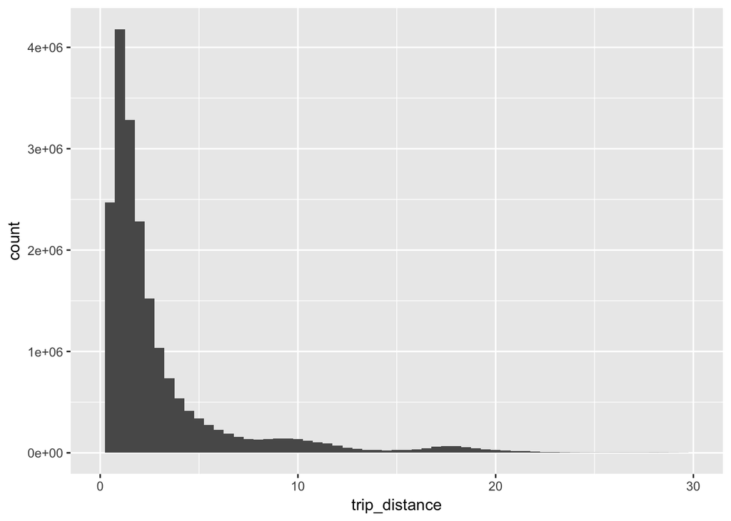

```r
ggplot(card, aes(trip_distance))+geom_histogram(binwidth = 0.5)+xlim(c(0,30))
```

```r
card <- card[card$trip_distance!=0,]
```

- We remove rate code ID since most of values are =1.

```r
table(card$RatecodeID)
```

```
##
##        1        2        3        4        5        6       99
## 19192884   451532    45497     9815    36371        7        6
```

```r
card$RatecodeID <- NULL
```

And we remove also the store_and_fw_flag since most of them are N.

```r
table(card$store_and_fwd_flag)
```

```
##
##        N        Y
## 19657138    78974
```

```r
card$store_and_fwd_flag <- NULL
```

To get some feeling on how tips are distributed we plot those limiting to maxium of 20 and showing negative values (likely wrong). We remove those negative values.

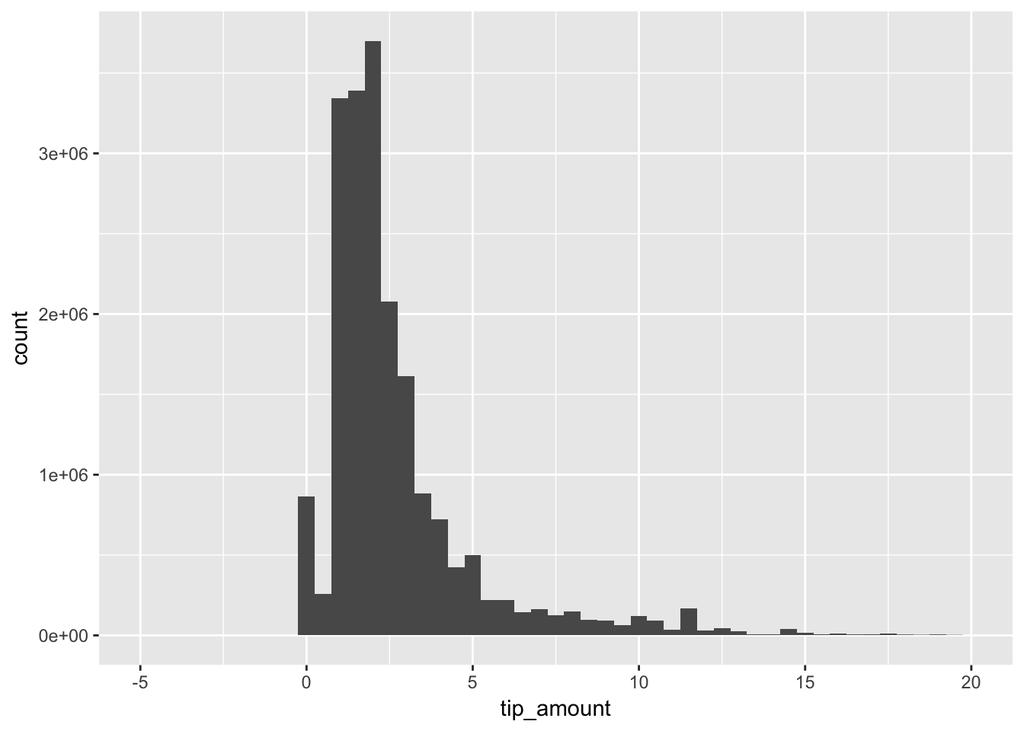

```r
ggplot(card, aes(tip_amount))+geom_histogram(binwidth = 0.5)+xlim(c(-5,20))
```

```r
card <- card[card$tip_amount >=0,]
```

## Feature Engineering:

- Having in mind that we have time series we see the need to enrich the dataset extracting hour of the day, day of the week, day of month,…For this test we only do for the dropoff time since we assume most of the values (except the seconds and maybe hours) will be the same. We create a field that excludes tip from total amount of money to use instead of total amount. Since in the API we should use this as parameter (without the tip)

```r
card$week_day <-wday(card$tpep_dropoff_datetime)
card$month_day <- mday(card$tpep_dropoff_datetime)
card$hour <- hour(card$tpep_dropoff_datetime)
card$year_day <- yday(card$tpep_dropoff_datetime)
card$trip_time <- difftime(card$tpep_dropoff_datetime,card$tpep_pickup_datetime, units = "secs")
card$tpep_pickup_datetime <- NULL
card$tpep_dropoff_datetime <- NULL
card$total_no_tip <- card$total_amount-card$tip_amount
```

- We plot some of the time variables and see that are peaks from 7 in the morning becoming flat at afternoon and additional peak at 19-22(back home?)

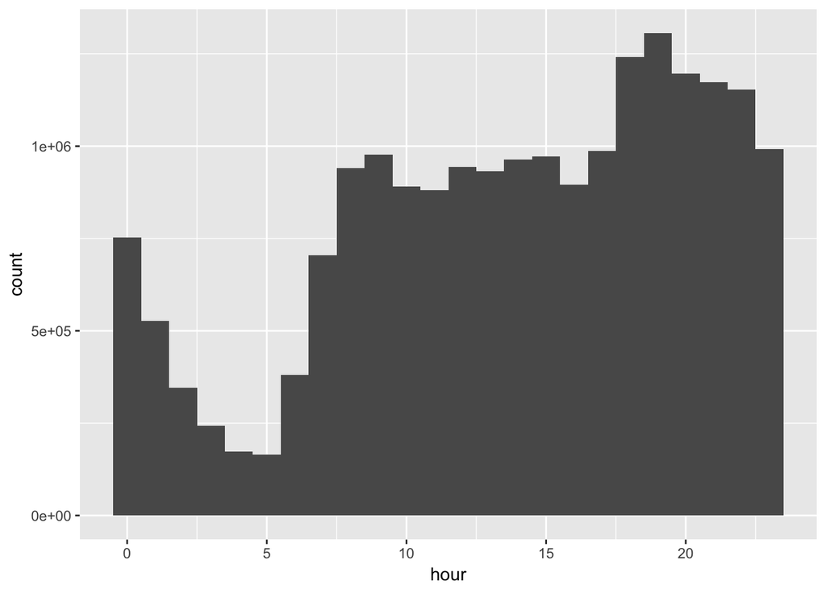

```r
ggplot(card, aes(hour))+geom_histogram(binwidth = 1)
```

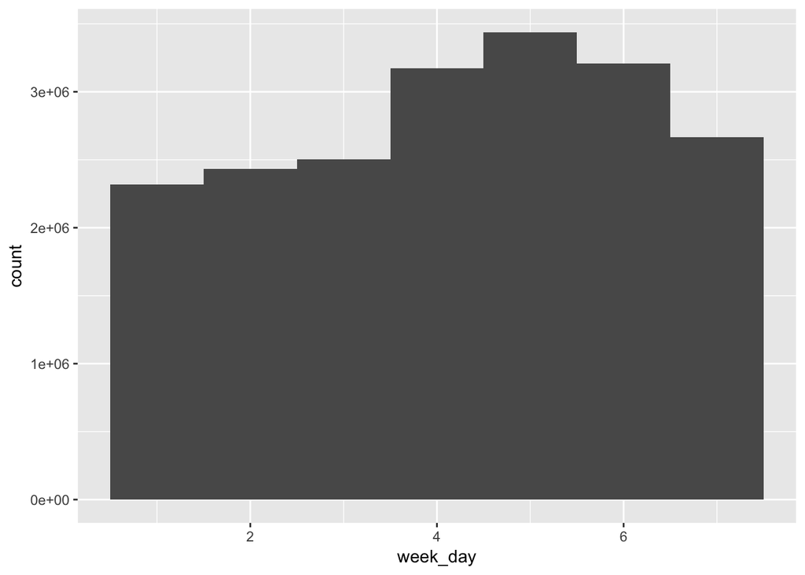

```r
ggplot(card, aes(week_day))+geom_histogram(binwidth = 1)
```

- We investigate a bit on how the total amount of money is distributed and we also remove those with 0 in total amount. We see a well distributed data being most of the trips around 8-15$.

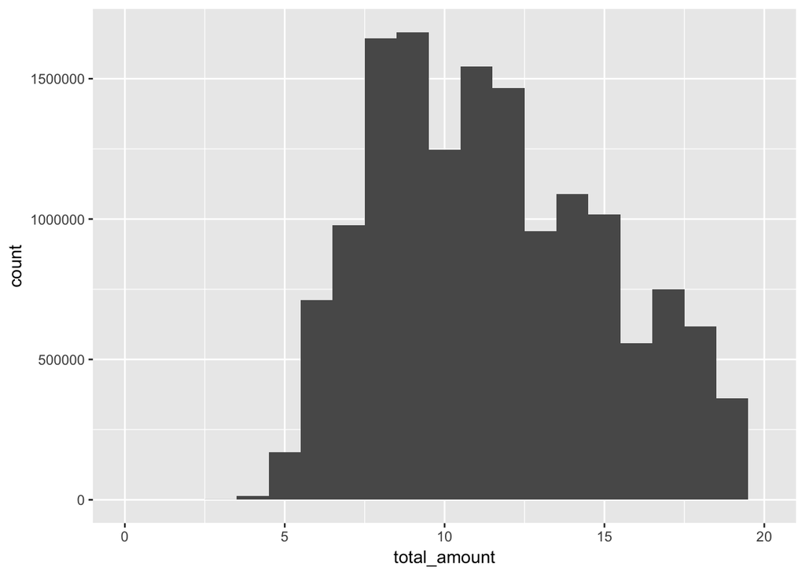

```r
ggplot(card, aes(total_amount))+geom_histogram(binwidth = 1)+xlim(c(0,20))
```

```r
card <- card[card$total_amount!=0,]
```

```r
set.seed(1)
sample_model <- sample_n(card, size =500000)
sample_model <- cbind(sample_model, dummy(sample_model$PULocationID, sep="_O_"))
sample_model <-cbind(sample_model, dummy(sample_model$DOLocationID, sep="_D_"))
sample_model$PULocationID <-NULL
sample_model$DOLocationID <-NULL
```

- We split dataset in train and test (0.8)

```r
set.seed(3456)
index <- createDataPartition(sample_model$tip_amount, p = .8,
                             list = FALSE,
                             times = 1)

taxi_train <- sample_model[index,]
taxi_test <- sample_model[-index,]
```

## Model:

```r
xgb <- xgboost(data =data.matrix(taxi_train[,-c(6,9)]), label = data.matrix(taxi_train[,6]), nrounds = 5, metric ="Accuracy")
```

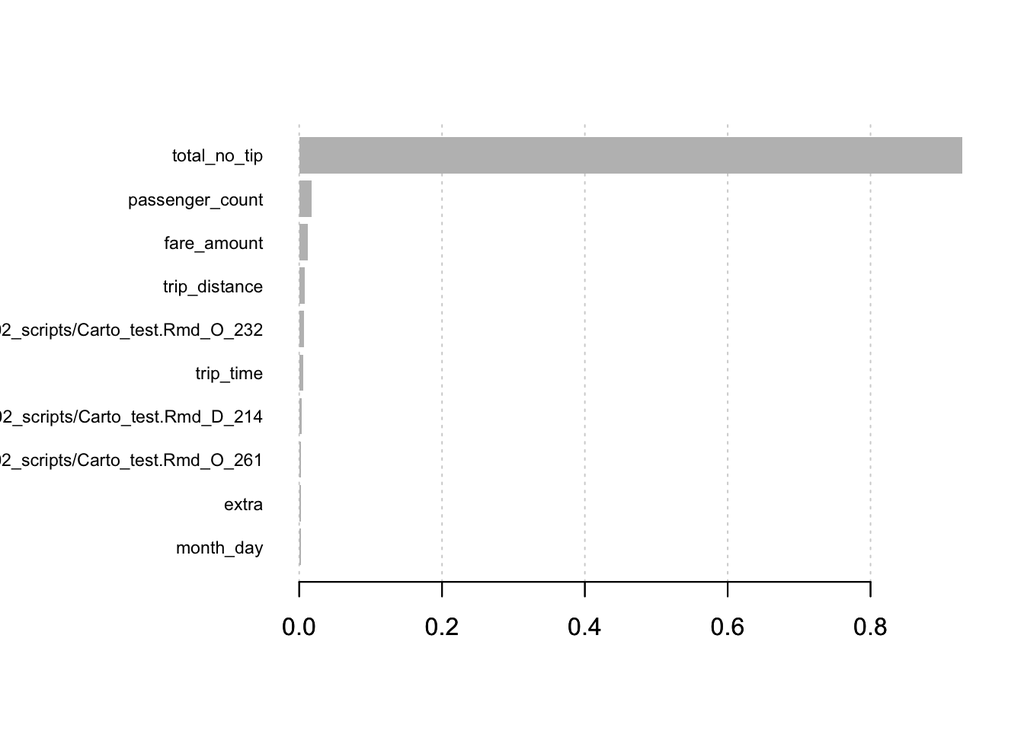

```r
importance_matrix <- xgb.importance(model =xgb)
xgb.plot.importance(importance_matrix[1:10,])
```

```r
test_predict <- predict(xgb, data.matrix(taxi_test[,-c(6,9)]))
```

```r
cor(test_predict,taxi_test$tip_amount)
```

```
## [1] 0.8150976
```

# Summary:

- Xgboost model seems to be reliabable and fast for this prediction. Further tests with a stratified sample based on tip amoung should be executed to see if behaviour remains the same or if there are discrepancies.
- Additional analysis on how the pickup area and dropoff area is needed to see if there is correlation with the tip.
- Same analysis for hour of the day and day of week would be interested to perform to see how those correlate with tip.
- Future developement:
  - Two models should be run to increase the accuracy:
  - First should be a classification model that would check if there will be a tip or not.
  - Second would be a regression model xgboost that will determine the amount of tip that will be given.
  - Add external variables as weather, bank holidays, special events (football matches,…), to better predict the tip amount and see if there is correlation of some of them with tip amount. Does people give extra tips if it is sunny? if it rains?…
  - Do further cleanup on outliers and odd values.